# Trabajo Práctico I. EEA

Alejandro Czernikier

19/10/2024

# 0. Carga de datos

```r
#Levantamos dataset
df <- read.csv("eph_train_2023.csv")
#View(df)
#glimpse(df)
#table(sapply(df,class))
```

El dataset cuenta con 11772 registros y 20 variables (10 categóricas y 10 numéricas). Las numéricas de interes son: edad, horas_trabajadas, educación, experiencia_potencial, salario y salario_horario

# 1. Análisis exploratiorio

```r
#Análisis de valores faltantes
exploratorio <- df %>%
  gather(., key="variables", value = "valores") %>%
  group_by(variables) %>%
  summarise(valores_unicos = n_distinct(valores),
  porcentaje_faltantes = sum(is.na(valores))/nrow(df)*100) %>%
  arrange(desc(porcentaje_faltantes), valores_unicos)

exploratorio
```

| variables | valores_unicos | porcentaje_faltantes |
| --- | --- | --- |
| asistencia_educacion | 3 | 0.008494733 |
| ano4 | 1 | 0.000000000 |
| trimestre | 1 | 0.000000000 |
| alfabetismo | 2 | 0.000000000 |
| cat_cantidad_empleos | 2 | 0.000000000 |
| sexo | 2 | 0.000000000 |
| tipo_establecimiento | 3 | 0.000000000 |
| categoria_ocupacion | 4 | 0.000000000 |
| nivel_ed | 6 | 0.000000000 |
| region | 6 | 0.000000000 |

[output cut: 10 more lines]

La única variable con valores faltantes es asistencia_educación, con porcentajes mínimos (1 Nan). Lo dropeo

```r
#Ubicamos fila con valor faltante
df_na <- df %>%
  filter(if_any(everything(), is.na))
df_na
```

| codusu | ano4 | trimestre | region | aglomerado | fecha_nacimiento | edad | asistencia_educacion | nivel_ed | tipo_establecimiento | codigo_actividad | sexo | categoria_ocupacion | cat_cantidad_empleos | alfabetismo | salario | horas_trabajadas | educacion | experiencia_potencial | salario_horario |
| --- | --- | --- | --- | --- | --- | --- | --- | --- | --- | --- | --- | --- | --- | --- | --- | --- | --- | --- | --- |
| TQRMNOPSXHJMPQCDEIJAH00812758 | 2023 | 3 | Gran Buenos Aires | 33 | 06/09/1985 | 37 | NA | Secundaria\nIncompleta | Estatal | 5601 | Mujer | Obrero o empleado | unico | Sabe leer y escribir | 43000 | 20 | 13 | 19 | 537.5 |

```r
#Al ser solo uno, lo dropeo
df <- df %>%
  drop_na()
```

```r
#Nos quedamos con variables de interes. Excluyo las colineales. P.ej: salario_horario fue calculado a partir de salario total y las horas trabajadas

df_1 <- df %>%
  select(edad, sexo, educacion, experiencia_potencial, salario_horario) %>%
  rename(exp_pot=experiencia_potencial,
         salario_h=salario_horario)
```

Boxplot univariado

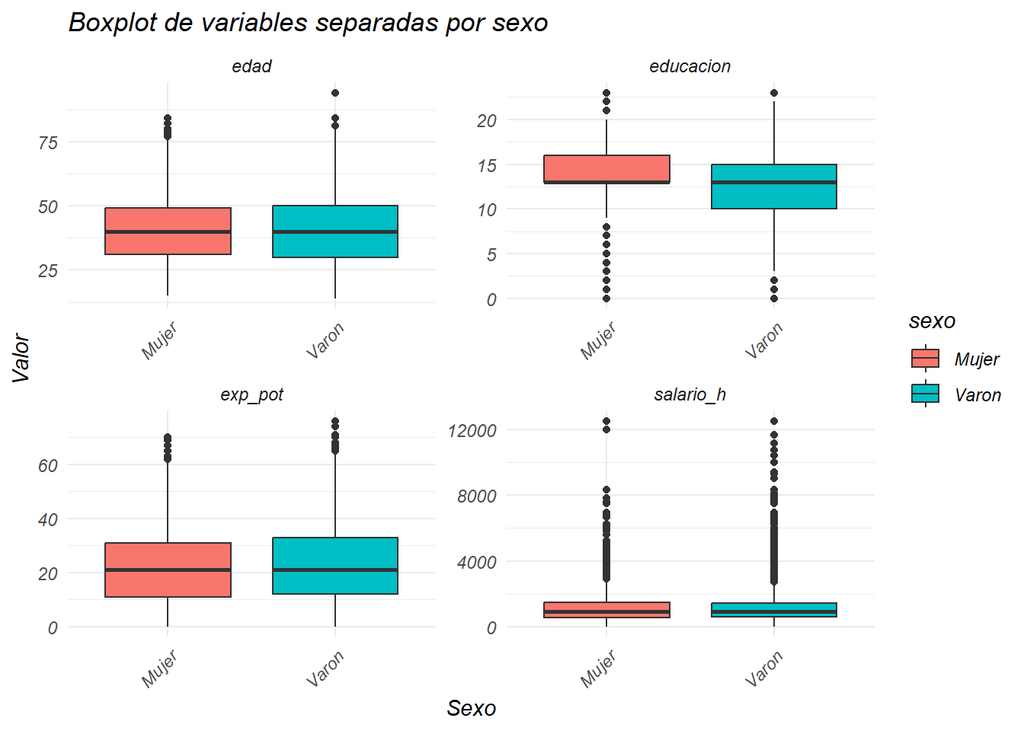

```r
# Convertir el dataset a formato largo para facilitar la creación del boxplot
df_long <- melt(df_1, id.vars = "sexo")

# Crear el boxplot
ggplot(df_long, aes(x = sexo, y = value, fill = sexo)) +
    geom_boxplot() +
    facet_wrap(~ variable, scales = "free") +
    theme_minimal() +
    labs(title = "Boxplot de variables separadas por sexo", x = "Sexo", y = "Valor") +
    theme(axis.text.x = element_text(angle = 45, hjust = 1))
```

La variable salario horario presenta numerosos outliers, seguido por la variable educación. Probé eliminando aquellos que superaban el 1er/3er cuartil en 1.5 veces el rango intercuartílico y el ajuste no mejoró, por lo cual decido dejar el dataset tal cual está.

Análisis de correlaciones

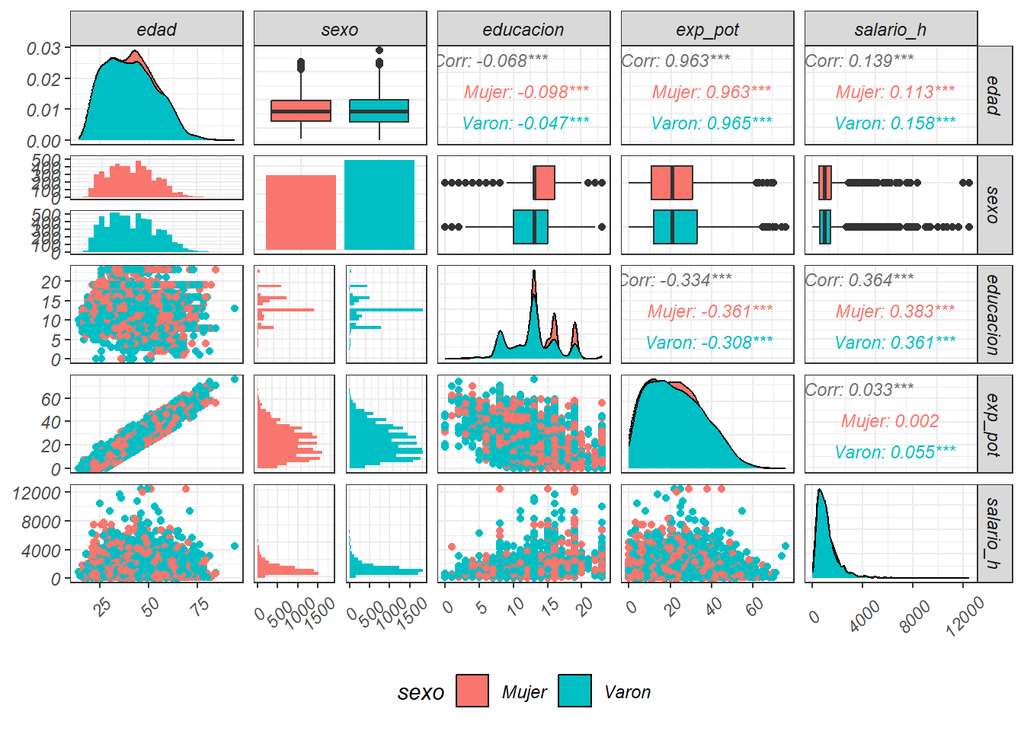

```r
#Grafico con ggpairs
df_1 %>%
  ggpairs(aes(color=sexo), upper = list(continuous = wrap("cor", size = 3, hjust=0.8, alignPercent=0.75)), legend = 25) +
  theme_bw() +
  theme(axis.text.x = element_text(angle=45, vjust=0.5), legend.position = "bottom")
```

Dentro de las asociaciones de interés, se observan correlaciones positivas del ingreso por hora con los años de educación, en menor medida con la edad y mínima con la experiencia potencial. Llamativamente se observa una asociacion negativa entre educación y edad, aunque muy leve. Respecto a la apertura por sexo la correlación de salario_hora con educación es ligeramente más fuerte en mujeres. Por su parte, la asociación con experiencia solo es significativa en varones. Por último el salario por hora de los varones correlaciona más fuertemente con la edad que el de las mujeres

Matrices de correlacion

```r
#Analizamos los coeficientes de correlación de Pearson y Spearman
#Pearson
matriz_tot <- df_1 %>%
  select_if(is.numeric) %>%
  correlate(use = "complete.obs", method = "pearson") %>%
  shave() %>%
  fashion()
```

```
## Correlation computed with
## • Method: 'pearson'
## • Missing treated using: 'complete.obs'
```

```r
matriz_tot
```

| term | edad | educacion | exp_pot | salario_h |
| --- | --- | --- | --- | --- |
| edad |  |  |  |  |
| educacion | -.07 |  |  |  |
| exp_pot | .96 | -.33 |  |  |
| salario_h | .14 | .36 | .03 |  |

```r
#Comparemos con matriz de Spearman, que es robusta y no requiere cumplimiento de normalidad
matriz_sp <-df_1 %>%
  select_if(is.numeric) %>%
  correlate(method = 'spearman') %>%
  shave() %>%
  fashion(decimals = 3)
```

```
## Correlation computed with
## • Method: 'spearman'
## • Missing treated using: 'pairwise.complete.obs'
```

```r
matriz_sp
```

| term | edad | educacion | exp_pot | salario_h |
| --- | --- | --- | --- | --- |
| edad |  |  |  |  |
| educacion | -.051 |  |  |  |
| exp_pot | .965 | -.292 |  |  |
| salario_h | .156 | .402 | .049 |  |

Con ambos métodos obtenemos una correlación positiva moderada del salario_horario con educación y baja con la edad y la experiencia. Los años de educación parecieran ser un buen predictor para salario horario

# 2. Modelo lineal experiencia

$$\text{E(SalarioHorario) = β0 + β1 Experiencia Potencial}$$

```r
# Creo modelo lineal de experiencia
modelo_exp = lm(formula = salario_h ~ exp_pot, data = df_1)
# Observamos que devuelve el modelo
modelo_exp
```

```
##
## Call:
## lm(formula = salario_h ~ exp_pot, data = df_1)
##
## Coefficients:
## (Intercept)      exp_pot
##    1133.439        2.373
```

Análisis de coeficientes Intercept: salario por hora esperado para alguien sin experiencia. exp_pot: por cada año de experiencia, el salario por hora esperado aumenta a razón de 2.37 pesos. Es decir que el impacto de un año más de experiencia será un aumeto de 2.37 pesos en el salario por hora esperado. Esto es independiente de los años de experiencia laboral que tenga (6 o 35)

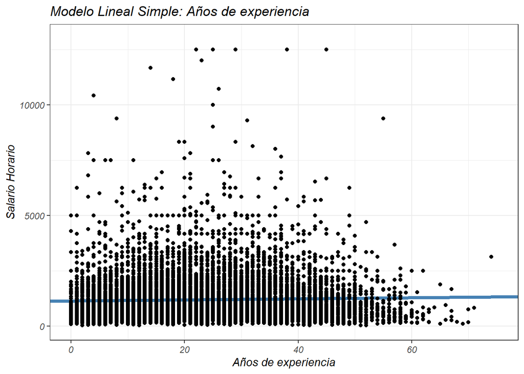

```r
#Graficamos modelo sobre datos observados

# Accedemos a la información de los coeficientes estimados
intercepto = modelo_exp$coefficients[1]
pendiente = modelo_exp$coefficients[2]

# Graficamos el dataset y el modelo
df_1 %>% ggplot(., aes(x = exp_pot, y = salario_h)) +
  geom_abline(intercept = intercepto, slope = pendiente, color="steelblue", size=1.5) + # capa del modelo
  geom_point() + #capa de los datos
  theme_bw() +
  scale_x_continuous(limits = c(0,75)) +
  scale_y_continuous(limits = c(0,13000)) +
  labs(title="Modelo Lineal Simple: Años de experiencia", x="Años de experiencia", y="Salario Horario")
```

Se aprecia que el ajuste no es bueno y se percibe que a partir de determinados años de experiencia el salario horario tiende a descender, algo no capturado por el ajuste lineal con pendiente positiva.

Modelo cuadrático experiencia

$$\text{E(SalarioHorario) = β0 + β1 Experiencia Potencial + β2
Experiencia Potencial^2}$$

```r
#Calculo el cuadrado de la experiencias
df_1$exp_pot_cuad <- df_1$exp_pot^2

modelo_exp_cuad = lm(formula = salario_h ~ exp_pot + exp_pot_cuad, data = df_1)
modelo_exp_cuad
```

```
##
## Call:
## lm(formula = salario_h ~ exp_pot + exp_pot_cuad, data = df_1)
##
## Coefficients:
##  (Intercept)       exp_pot  exp_pot_cuad
##     913.5271       26.9755       -0.4862
```

Graficamos

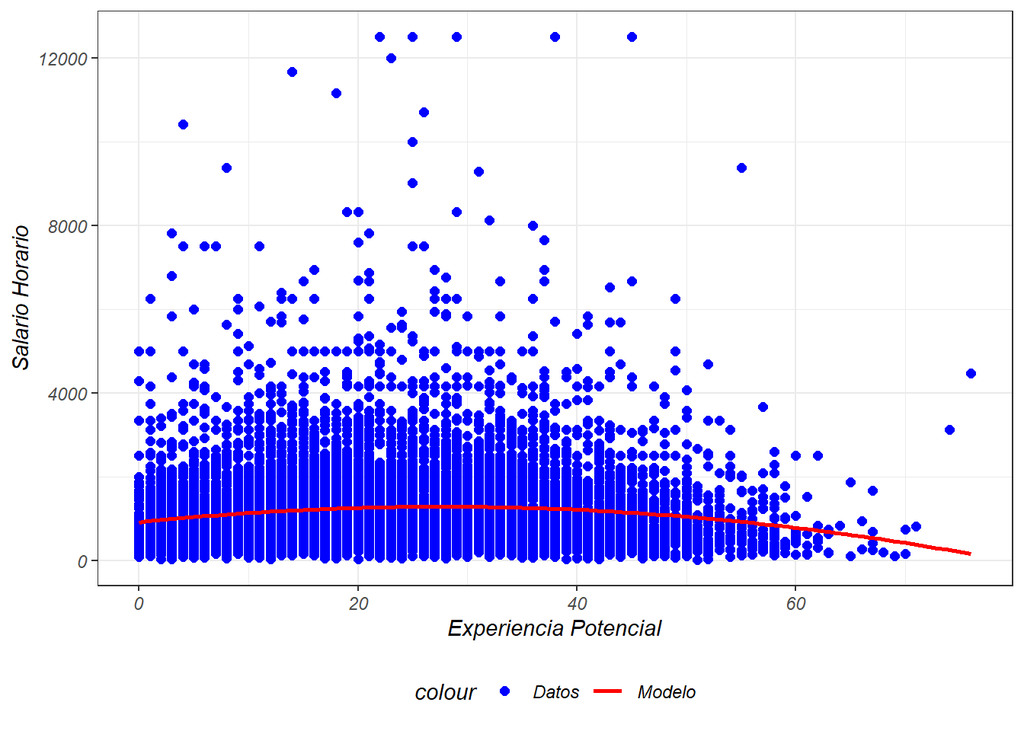

```r
# Crear un rango de valores para exp_pot
exp_pot_seq <- seq(min(df_1$exp_pot), max(df_1$exp_pot), length.out = 100)

# Calcular los valores predichos usando el modelo
predicciones <- 913.534 + 26.966 * exp_pot_seq - 0.486 * exp_pot_seq^2

# Crear un dataframe para las predicciones
df_predicciones <- data.frame(exp_pot = exp_pot_seq, salario_h = predicciones)

# Graficar los datos y el modelo cuadrático
ggplot(df_1, aes(x = exp_pot, y = salario_h)) +
  geom_point(aes(color = "Datos"), size = 2) +  # Datos originales
  geom_line(data = df_predicciones, aes(x = exp_pot, y = salario_h, color = "Modelo"), size = 1) +  # Línea del modelo
  labs(x = "Experiencia Potencial", y = "Salario Horario") +
  theme_bw() +
  scale_color_manual(values = c("Datos" = "blue", "Modelo" = "red")) +
  theme(legend.position = "bottom")
```

Dado que el coeficiente asociado al cuadrado de la experiencia potencial es negativo, a determinada edad el salario_h esperado comienza a caer. La tasa de cambio del salario horario se obtiene a partir de la derivada en función de la experiencia potencial

$$\frac{d(\text{salario_h})}{d(\text{exp_pot})} = 26.966 - 2 \cdot 0.486
\cdot \text{exp_pot} \quad[1]$$

Donde es igual a cero, indica el valor de exp_pot donde el salario_h esperado comienza a caer

$$0 = 26.966 - 2 \cdot 0.486 \cdot \text{exp_pot}$$

$$\text{exp_pot} ≈27.74$$

A partir de los 28 años de experiencia, el salario por hora esperado comienza a descender.

El impacto de un año más de experiencia dependerá de los años de experiencia en que se lo esté analizado. Resolviendo [1] se obtiene que el efecto sobre el salario horario esperado de un año más de experiencia laboral para una persona con 6 años de experiencia laboral es de 21.134 en tanto que para una personas con 35 años de experiencia laboral el efecto es de -7.054. Es decir que un año de experiencia adicional reduce el salario horario esperado en 7.054 pesos

# 3. Modelo múltiple: se plantea un primer modelo a partir de la ecuación de Mincer:

$$\text{E(SalarioHorario) = β0 + β1 Años Educacion + β2 Experiencia
Potencial + β3 Experiencia Potencial^2+
β4 Sexo + β5 Sexo · Años Educación}$$

Al incluir la variable categórica sexo comenzaremos por evaluar variación de salario horario por sexo

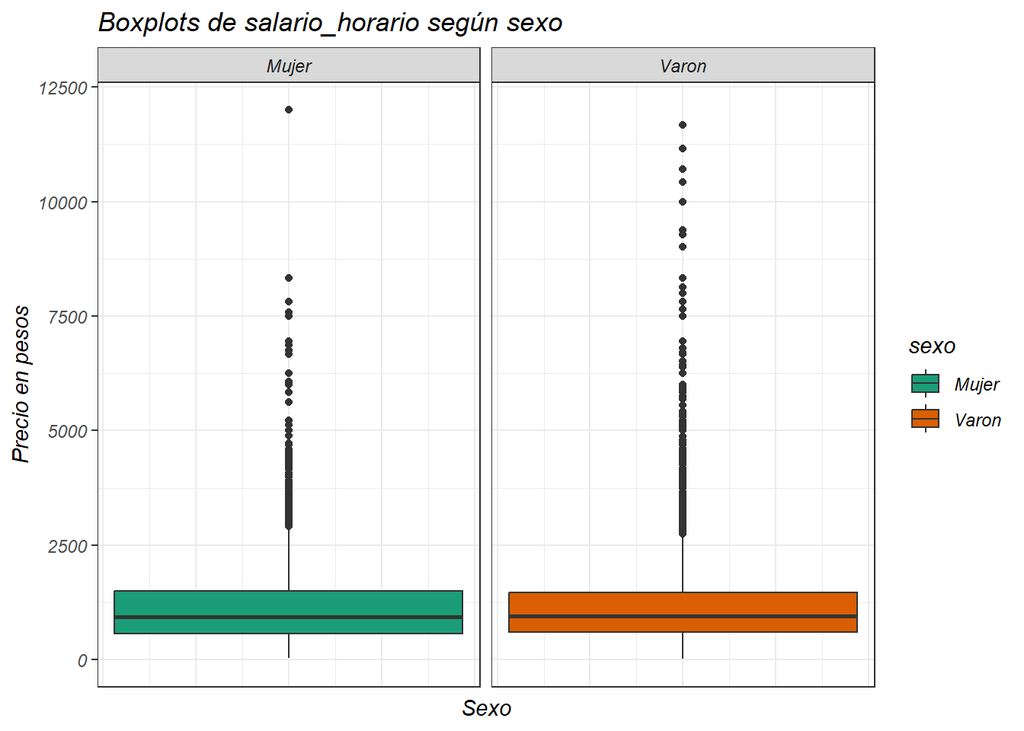

```r
ggplot(data = df_1, aes(y = salario_h, group = sexo, fill = sexo)) +
         geom_boxplot() +
         scale_fill_brewer(palette="Dark2") +
  theme_bw() +
  scale_y_continuous(limits = c(0, 12000)) +
  theme(axis.text.x=element_blank(),
        axis.ticks.x=element_blank()) +
         labs(title = "Boxplots de salario_horario según sexo") +
  labs(y = "Precio en pesos") +
  labs(x = "Sexo") +
  facet_wrap(~sexo)
```

Analizando la variable sexo en función de la variable a predecir, no se observan grandes diferencias en el salario por hora según el sexo. Los varones parecieran presentar un salario por hora levemente mayor, con mayor número de valores extremos. La dispersión es similar por sexo.

```r
#Ajustamos el modelo planteado
modelo_mult <- lm(salario_h ~ educacion + exp_pot + exp_pot_cuad + sexo + sexo*educacion, data = df_1)
tidy_mult <- tidy(modelo_mult, conf.int = TRUE)
tidy_mult
```

| term | estimate | std.error | statistic | p.value | conf.low | conf.high |
| --- | --- | --- | --- | --- | --- | --- |
| (Intercept) | -834.1888622 | 57.03823674 | -14.625082 | 5.124126e-48 | -945.9932542 | -722.3844702 |
| educacion | 118.3936099 | 3.57182129 | 33.146566 | 2.058840e-230 | 111.3922486 | 125.3949713 |
| exp_pot | 23.9959519 | 2.07276867 | 11.576763 | 7.938662e-31 | 19.9329819 | 28.0589218 |
| exp_pot_cuad | -0.2273108 | 0.03952391 | -5.751223 | 9.080578e-09 | -0.3047842 | -0.1498374 |
| sexoVaron | 225.2246089 | 63.60507487 | 3.540985 | 4.001774e-04 | 100.5481264 | 349.9010914 |
| educacion:sexoVaron | -6.4425230 | 4.61741069 | -1.395267 | 1.629615e-01 | -15.4934128 | 2.6083668 |

La primera aparición de la variable categórica es “Mujer” por lo tanto esta es tomada como el valor de referencia.

Intercept (β0 = -834.19) El salario horario esperado para una mujer cuando el resto de los regresores son cero, es decir sin años de educación ni experiencia. Carece de sentido práctico pero al ser significativamente distinto de cero (Ho) resulta importante para el ajuste del modelo

Años de Educación (β1 = 118.39): Efecto principal de la educación en el salario. Este coeficiente indica que, manteniendo constantes las demás variables (es decir, dados los años de experiencia y el sexo), por cada año adicional de educación, se espera que el salario horario aumente en 118.39 pesos. El p-valor extremandamente bajo implica la significativaidad de esta variable para explicar el salario por hora (tal como lo habíamos intuído en la matriz de correlaciones)

Dado que los coeficientes vinculados a la experiencia potencial son cuadráticos deben interpretarse como en el caso anterior: basícamente el salario aumenta a medida que se gana experiencia, pero a un ritmo decreciente y en determinado momento el aumento en los años de experiencia tiene un efecto negativo en el salario por hora. Aún así ensayamos una interpretación de los coeficientes individuales:

Experiencia Potencial (β2 = 23.99): Componente lineal de la experiencia. Este coeficiente sugiere que, dado el sexo y manteniendo las demás variables constantes (algo imposible por el componente cuadratico), por cada año adicional de experiencia potencial, el salario horario se incrementa en aproximadamente 24 pesos. Es significativo para explicar el salario horario.

Experiencia Potencial al Cuadrado (β3 = -0.227): Componente cuadrático de la experiencia. Como es negativo, sugiere que, dado el sexo y los años de educación, a medida que aumenta la experiencia, el efecto incremental sobre el salario disminuye. Este término captura el efecto no lineal de la experiencia, mostrando que, tras cierto punto, los incrementos en la experiencia potencial tienen un efecto decreciente sobre el salario. Es significativo para explicar el salario por hora.

SexoVaron (β4 = 225.22) Efecto principal del sexo: la diferencia en la media de salario por hora de varones respecto a mujeres cuando el resto de los regresores son constantes. Es decir, cuanto más cobra por hora un varón respecto a una mujer, dados los años de educación y experiencia. Sin embargo, este efecto puede estar modificado por la interacción con la educación. Aun así esta variable categórica es significativa para explicar el salario por hora.

Interacción SexoVaron · Años de Educación (β5 = -6.44): Este coeficiente indica cómo el efecto de la educación en el salario varía dependiendo del sexo, dados los años de experiencia. En este caso, por cada año adicional de educación, el salario de los varones aumenta 6.44 pesos menos que el de las mujeres, lo que significa que el efecto de la educación es ligeramente menor para los varones. Ahora bien, dado que el coeficiente no es estadísticamente significativo (p-valor = 0.162), no hay suficiente evidencia para afirmar que el efecto de la educación sea diferente entre varones y mujeres en este modelo, dados los años de experiencia.

En resumen, la educación y la experiencia son predictores significativos postivos del salario por hora. El sexo también tiene un efecto considerable (los varones tienen un salario significativamente más alto que las mujeres en promedio). Por último la interacción entre sexo y educación no pareciera ser relevante, es decir el efecto de la educación en el salario no depende del sexo en este modelo.

Análisis significatividad global

```r
summary(modelo_mult)
```

```
##
## Call:
## lm(formula = salario_h ~ educacion + exp_pot + exp_pot_cuad +
##     sexo + sexo * educacion, data = df_1)
##
## Residuals:
##     Min      1Q  Median      3Q     Max
## -2360.6  -498.1  -161.4   276.2 11803.4
##
## Coefficients:
##                       Estimate Std. Error t value Pr(>|t|)
## (Intercept)         -834.18886   57.03824 -14.625  < 2e-16 ***
## educacion            118.39361    3.57182  33.147  < 2e-16 ***
## exp_pot               23.99595    2.07277  11.577  < 2e-16 ***
## exp_pot_cuad          -0.22731    0.03952  -5.751 9.08e-09 ***
## sexoVaron            225.22461   63.60507   3.541   0.0004 ***
## educacion:sexoVaron   -6.44252    4.61741  -1.395   0.1630
## ---
## Signif. codes:  0 '***' 0.001 '**' 0.01 '*' 0.05 '.' 0.1 ' ' 1
##
## Residual standard error: 886.6 on 11765 degrees of freedom
## Multiple R-squared:  0.1671, Adjusted R-squared:  0.1668
## F-statistic: 472.1 on 5 and 11765 DF,  p-value: < 2.2e-16
```

Analizando el test de significatividad global F que plantea:

$$\text{H}_0: \, \beta_1 = \beta_2 = \cdots = \beta_{p-1} = 0 \\
\text{H}_1: \, \text{no todos los } \beta_k \, (k=1, 2, \dots, p-1) \,
\text{son iguales a 0}$$

Dado que el p-valor es < 2.2e-16 confirmamos que al menos una variable regresora sirve para explicar el salario horario, es decir el modelo es globalmente significativo. Por su parte R-cuadrado/R-cuadrado ajustado ~0.167 significa que el modelo explica el aproximadamente 16.7% de la variabilidad en el salario horario

Graficamos abriendo por sexo

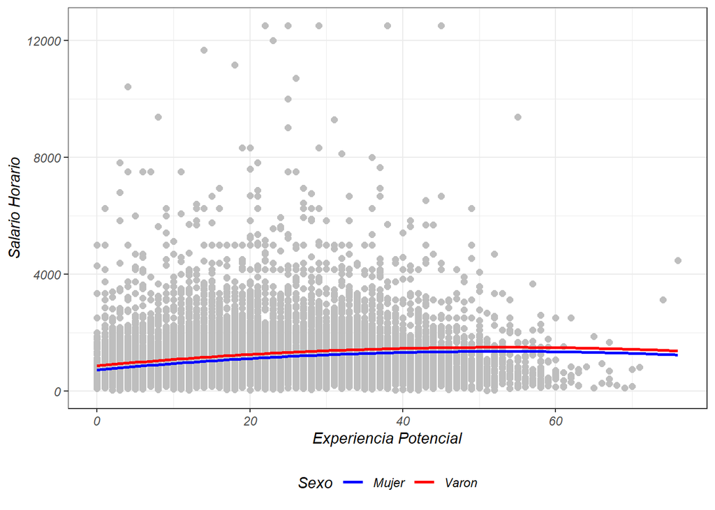

```r
# Crear un rango de valores para exp_pot
exp_pot_seq <- seq(min(df_1$exp_pot), max(df_1$exp_pot), length.out = 100)
educacion_promedio <- mean(df_1$educacion)  # Usamos la media de educación como referencia

# Crear predicciones separadas por sexo
predicciones_mujer <- predict(modelo_mult,
                              newdata = data.frame(exp_pot = exp_pot_seq,
                                                   exp_pot_cuad = exp_pot_seq^2,
                                                   educacion = educacion_promedio,
                                                   sexo = "Mujer"))
predicciones_varon <- predict(modelo_mult,
                              newdata = data.frame(exp_pot = exp_pot_seq,
                                                   exp_pot_cuad = exp_pot_seq^2,
                                                   educacion = educacion_promedio,
                                                   sexo = "Varon"))

# Crear un dataframe para las predicciones
df_predicciones <- data.frame(exp_pot = rep(exp_pot_seq, 2),
                              salario_h = c(predicciones_mujer, predicciones_varon),
                              sexo = rep(c("Mujer", "Varon"), each = length(exp_pot_seq)))

# Graficar los datos y las predicciones por sexo
ggplot() +
  geom_point(data = df_1, aes(x = exp_pot, y = salario_h), color = "grey", size = 2) +  # Datos originales en gris
  geom_line(data = df_predicciones, aes(x = exp_pot, y = salario_h, color = sexo), size = 1) +  # Línea del modelo por sexo
  labs(x = "Experiencia Potencial", y = "Salario Horario", color = "Sexo") +
  theme_bw() +
  scale_color_manual(values = c("Mujer" = "blue", "Varon" = "red")) +
  theme(legend.position = "bottom")
```

Cumplimiento supuestos

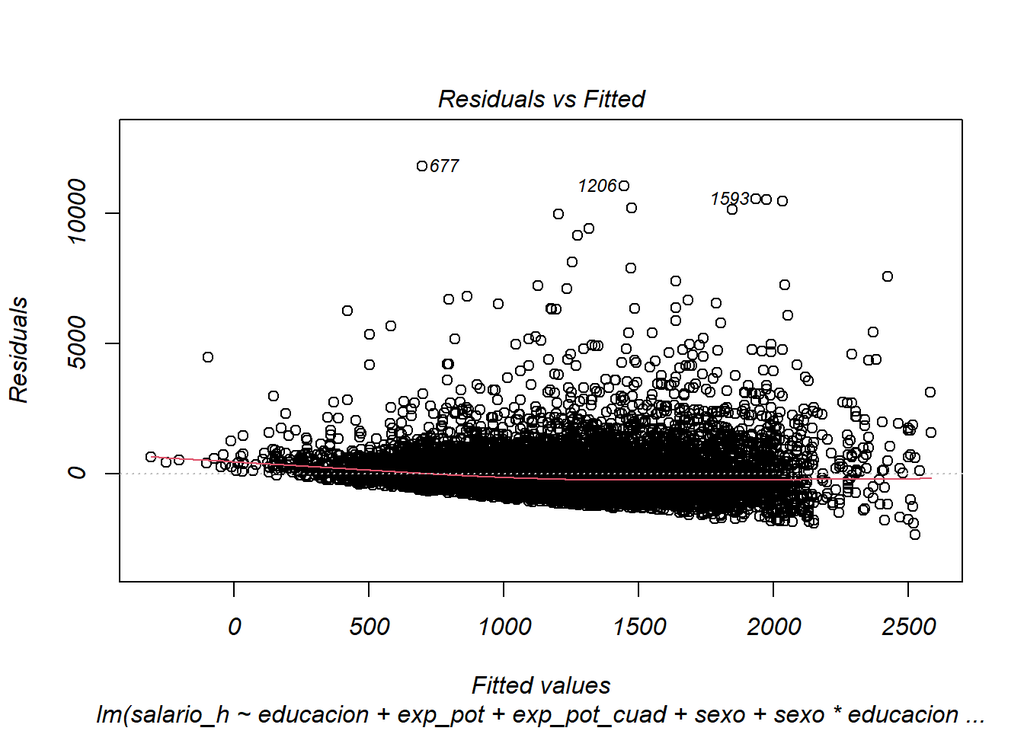

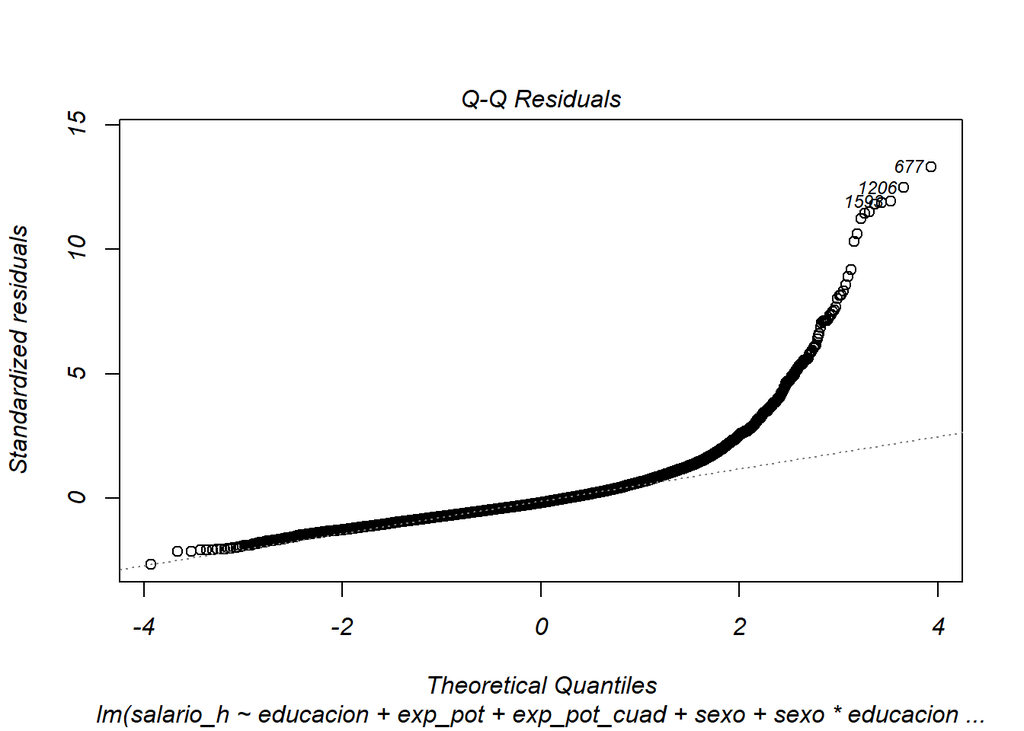

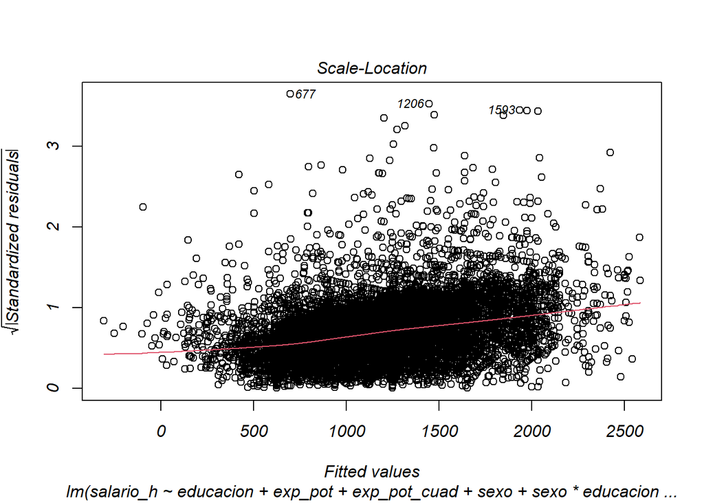

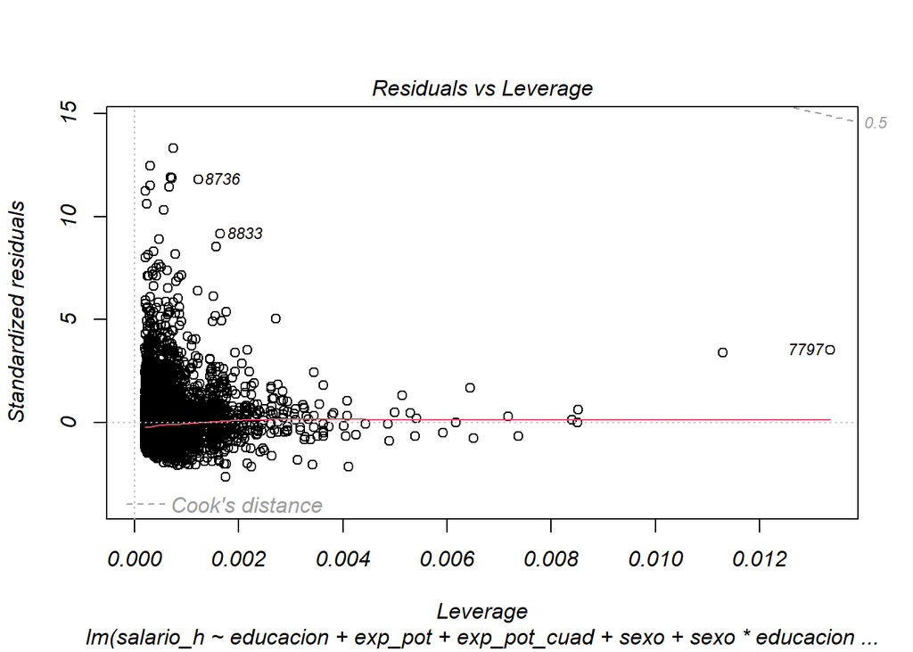

```r
plot(modelo_mult)
```

Normal QQ plot: Gran parte de los residuos estandarizados no se ajustan a la curva teórica ~N(0,1), sobretodo los del extremo superior.

Scale-location plot: Se observa estructura en los datos, con la raíz de los residuos estandarizados aumentando a medida que crece los predichos.

Residual vs leverage: Ningun punto por encima de la línea de Cook, que indica mediciones muy influyentes. La mayoría de los puntos se encuentran cerca de la línea horizontal en el eje Y, lo que sugiere que la mayoría de las observaciones tienen residuos relativamente pequeños y no son influyentes. Si hay puntos con alto Leverage(7797) y alto residuos (8736 y 8833) sugiriendo su influencia en el modelo.

```r
df_1[c(7797,8736,8833),]
```

|  | edad | sexo | educacion | exp_pot | salario_h | exp_pot_cuad |
| --- | --- | --- | --- | --- | --- | --- |
| 7797 | 94 | Varon | 13 | 76 | 4464.286 | 5776 |
| 8736 | 69 | Mujer | 19 | 45 | 12500.000 | 2025 |
| 8833 | 71 | Varon | 11 | 55 | 9375.000 | 3025 |

```r
# Calcular las medias solo para columnas numéricas en df_1
medias_numericas <- colMeans(df_1[sapply(df_1, is.numeric)], na.rm = TRUE)

# Mostrar los resultados
print(medias_numericas)
```

```
##         edad    educacion      exp_pot    salario_h exp_pot_cuad
##     40.55552     13.17492     22.38315   1186.55980    680.33642
```

Los puntos con alto leverage efectivamente se alejan de todas las medias (salvo educación)

Diagnóstico: el modelo no cumple con los supuestos del modelo lineal. Dada la violación del de linealidad de la esperanza condicional, falta de normalidad y presencia de observaciones de alto leverage

# 4. Modelo de Mincer “enriquecido”

$$\text{E [ln(SalarioHorario)] = β0 +β1 Años Educacion + β2 Experiencia
Potencial + β3 Experiencia Potencial^2+
β4Sexo + β5Sexo · AñosEducacion}$$

```r
# Dado que vamo sa trabajar con el logartimo de salario_horario, verificar que no haya valores iguales a cero o negativos
hay_valores_invalidos <- any(df_1$salario_h <= 0)

# Mostrar el resultado
if (hay_valores_invalidos) {
  cat("Existen valores cero o negativos en la columna 'salario_h'.\n")
} else {
  cat("No hay valores cero o negativos en la columna 'salario_h'.\n")
}
```

```
## No hay valores cero o negativos en la columna 'salario_h'.
```

```r
# Ajustar el modelo para E[ln(SalarioHorario)]
modelo_mincer <- lm(log(salario_h) ~ educacion + exp_pot + exp_pot_cuad + sexo + sexo * educacion, data = df_1)

# Obtener un resumen del modelo con intervalos de confianza
tidy_mincer <- tidy(modelo_mincer, conf.int = TRUE)

# Mostrar los resultados
print(tidy_mincer)
```

```
## # A tibble: 6 × 7
##   term                 estimate std.error statistic   p.value conf.low conf.high
##   <chr>                   <dbl>     <dbl>     <dbl>     <dbl>    <dbl>     <dbl>
## 1 (Intercept)          5.15     0.0418       123.   0          5.06e+0  5.23
## 2 educacion            0.0963   0.00261       36.8  4.41e-281  9.12e-2  0.101
## 3 exp_pot              0.0240   0.00152       15.8  9.36e- 56  2.10e-2  0.0270
## 4 exp_pot_cuad        -0.000293 0.0000289    -10.1  5.67e- 24 -3.50e-4 -0.000236
## 5 sexoVaron            0.280    0.0466         6.02 1.81e-  9  1.89e-1  0.372
## 6 educacion:sexoVaron -0.0115   0.00338       -3.41 6.45e-  4 -1.82e-2 -0.00491
```

El coeficiente asociado a la varible educación indica que, dados los demás regresores, por cada año adicional de educación, se espera que el logaritmo del salario horario aumente en 0.0963. Esto puede expresarse como

$$\Delta \ln(\text{salario_h}) \approx 0.0963$$

Resolviendo la exponencial
$$e^{0.0963} \approx 1.101$$

Lo que indica que por cada año de educación el salario_horario esperado aumentará en un 10.1% respecto al salario anterior. El p-valor es extremadamente bajo, implicando que esta variable es significativa para explicar el logaritimo del salario esperado por hora.

Comparamos la significatividad individual de los coeficientes entre ambos modelos.

```r
# Extraer coeficientes de ambos modelos
coef_mincer <- tidy_mincer %>% select(term, p.value) %>% rename(p.value_log = p.value)
coef_mult <- tidy_mult %>% select(term, p.value) %>% rename(p.value_mult = p.value)

# Unir ambos dataframes por el término (coeficiente)
comparacion_coef <- left_join(coef_mincer, coef_mult, by = "term")

# Mostrar el dataframe de comparación
print(comparacion_coef)
```

```
## # A tibble: 6 × 3
##   term                p.value_log p.value_mult
##   <chr>                     <dbl>        <dbl>
## 1 (Intercept)           0            5.12e- 48
## 2 educacion             4.41e-281    2.06e-230
## 3 exp_pot               9.36e- 56    7.94e- 31
## 4 exp_pot_cuad          5.67e- 24    9.08e-  9
## 5 sexoVaron             1.81e-  9    4.00e-  4
## 6 educacion:sexoVaron   6.45e-  4    1.63e-  1
```

Todos los p-valores son menores para este modelo que para el múltiple, indicando mayor significatividad. A su vez, en este modelo es significativo el p-valor de la interacción educación * sexo. En este caso el coeficiente de para esta variable es ~ -0.012 indicando que la relación entre años de educación y salario_horario es más débil para los hombres que para las mujeres. Es decir, por cada año adicional de educación, el aumento en el salario horario para los hombres es menor en comparación con el de las mujeres.

Variabilidad explicada

```r
summary(modelo_mincer)
```

```
##
## Call:
## lm(formula = log(salario_h) ~ educacion + exp_pot + exp_pot_cuad +
##     sexo + sexo * educacion, data = df_1)
##
## Residuals:
##     Min      1Q  Median      3Q     Max
## -3.4783 -0.3808  0.0346  0.4187  3.0285
##
## Coefficients:
##                       Estimate Std. Error t value Pr(>|t|)
## (Intercept)          5.146e+00  4.176e-02 123.226  < 2e-16 ***
## educacion            9.630e-02  2.615e-03  36.826  < 2e-16 ***
## exp_pot              2.400e-02  1.517e-03  15.814  < 2e-16 ***
## exp_pot_cuad        -2.928e-04  2.894e-05 -10.120  < 2e-16 ***
## sexoVaron            2.803e-01  4.656e-02   6.019 1.81e-09 ***
## educacion:sexoVaron -1.154e-02  3.380e-03  -3.413 0.000645 ***
## ---
## Signif. codes:  0 '***' 0.001 '**' 0.01 '*' 0.05 '.' 0.1 ' ' 1
##
## Residual standard error: 0.6491 on 11765 degrees of freedom
## Multiple R-squared:  0.1936, Adjusted R-squared:  0.1933
## F-statistic:   565 on 5 and 11765 DF,  p-value: < 2.2e-16
```

Este modelo explica aproximadamente el 19,3% de la variabilidad del logaritmo del salario horario. Para comparar con el modelo anterior, donde la variable dependiente era el salario horario, debemos calcular la exponencial de los predichos por este modelo y partir de ahí calcular el R2. Dado que ambos modelos tienen igual cantidad de variables, los R2 son comparables

```r
predicciones_mincer <- exp(predict(modelo_mincer)) #Predigo con la exponencial
R2_mincer <- cor(df_1$salario_h, predicciones_mincer)^2
# R^2 para el modelo múltiple
R2_mult <- summary(modelo_mult)$r.squared

df_comparacion_r2 <- data.frame(
  modelo = c("modelo_mincer", "modelo_mult"),
  R2 = c(R2_mincer, R2_mult)
)

# Ver el data frame de comparación
df_comparacion_r2
```

| modelo | R2 |
| --- | --- |
| modelo_mincer | 0.1789594 |
| modelo_mult | 0.1671140 |

Entonces este modelo explica el 17.9% de la variabilidad del salario horario, lo cual representa una leve mejora respecto el 16.7% del modelo anterior.

……………………………..

Ligera disgreción: en internet vi que una métrica posible para comparar estos dos modelos era el pseudo-R2. Lo agrego pero no estoy seguro de su utilidad.

Calculamos el pseudo R

```r
#Funcion para calcular el pseudo R

pse_r <- function(modelo, df_columna){
  pred_log <- predict(modelo)  # Predicciones logarítmicas
  pred_original <- exp(pred_log)   # Predicciones en la escala original

  errores_residuales <- df_columna - pred_original #Calculo residuos

  varianza_original <- var(df_columna) #Varianza original
  varianza_residual <- var(errores_residuales) #Varianza del residuo

  pseudo_r2 <- 1 - (varianza_residual / varianza_original)

  return (pseudo_r2)
  }

cat("Pseudo R2 modelo mincer:", pse_r(modelo_mincer, df_1$salario_h), "\n")
```

```
## Pseudo R2 modelo mincer: 0.171322
```

Con el pseudo R2 también se obtiene un mayor valor que el R2 para el modelo multiple ……………………………………………………………….

Comprobación supuestos

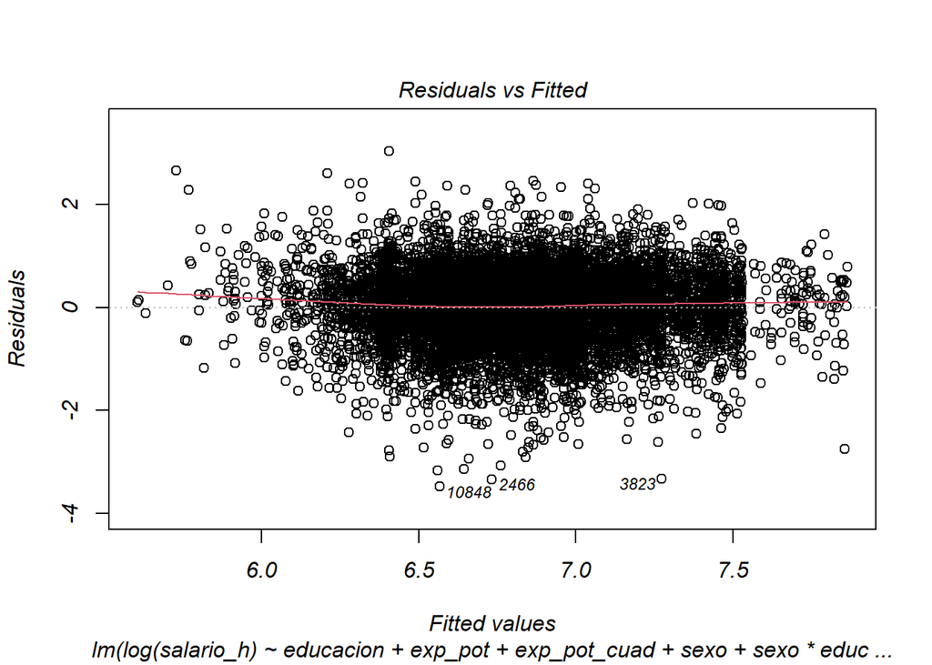

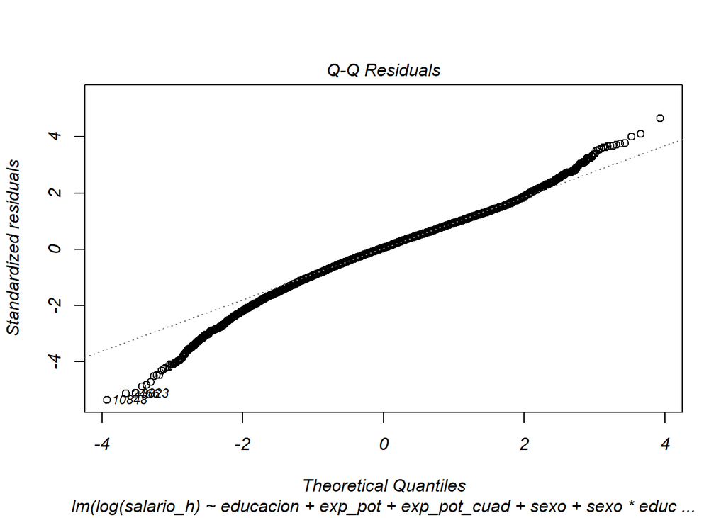

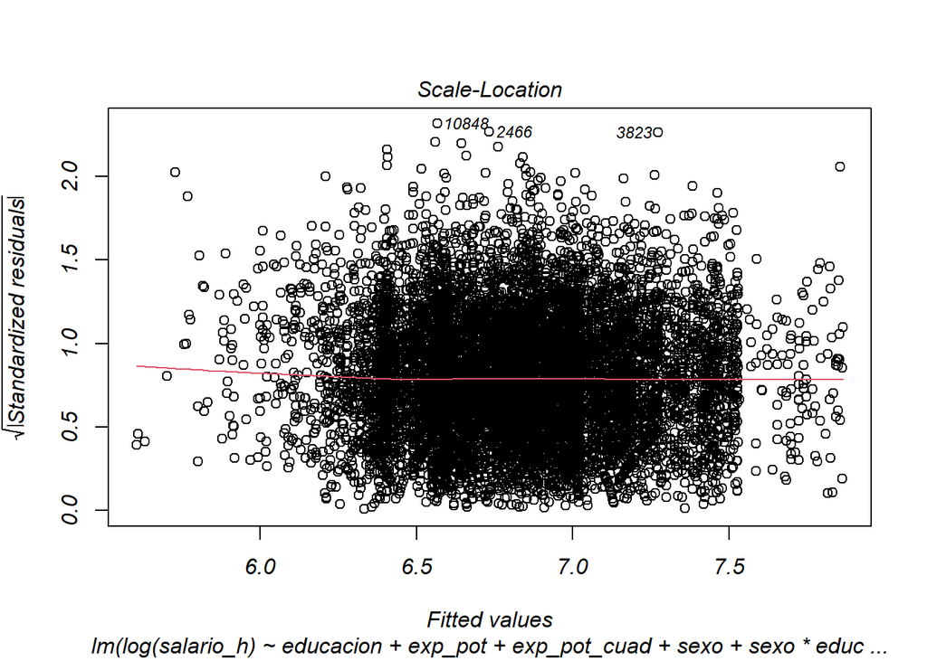

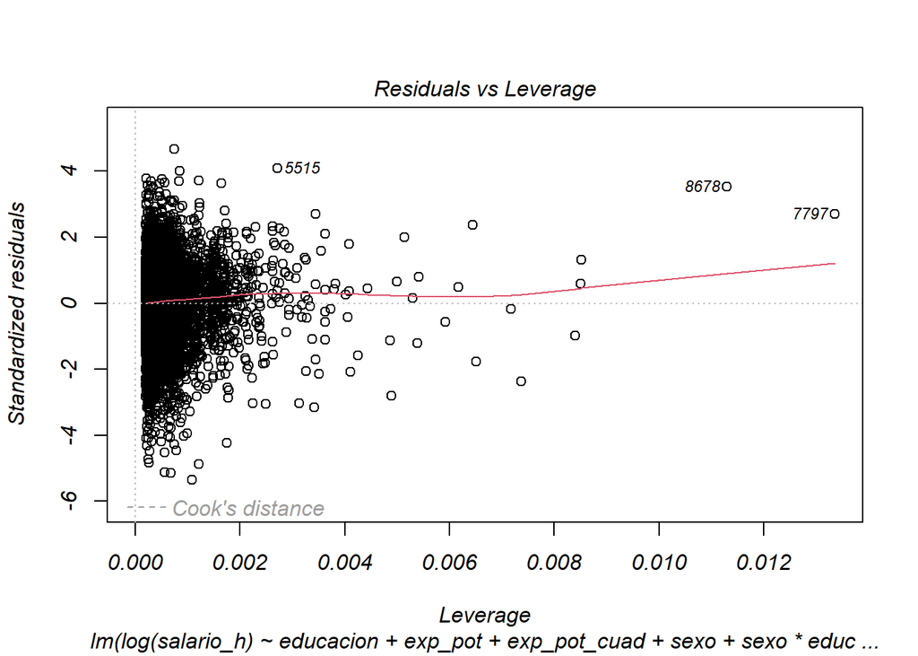

```r
plot(modelo_mincer)
```

Residuos vs valores predichos Los residuos se distribuyen más aleatoriamente alrededor del cero que en el modelo anterior, sin estructura. La variabilidad parece constante alrededor de los predichos, sugiriendo homocedasticidad. Hay sin embargo algunos valores (10848, 2466, 3823) que parecieran ser outliers

Normal QQ plot: Una mayor propoción de los residuos estandarizados se ajustan a la curva teórica ~N(0,1).Los puntos en las colas se desvían de la línea diagonal, lo que sugiere que hay algunos valores atípicos o que los residuos en estos extremos no siguen completamente una distribución normal. Los puntos 10848 y 3823 nuevamente aparecen aquí, lo que confirma que son posibles outliers o influencias fuertes en el modelo.

Residuos estandarizados:Nuevamente no se observan un patrón, aunque hay varios valores (correspondientes a los mismos de antes)de la raíz del residuo estandarizado que están más allá del 2, nuevamente, parecieran corresponder a outliers

Diagnóstico: este modelo cumple en mayor grado con los supuestos del modelo lineal en comparación con el modelo anterior, lo cual, teniendo en cuenta el aumento en el grado de variabilidad del salario horario explicado lo hace más atractivo. Es importante remarcar sin embargo la presencia de diversos valores atípicos que debieran ser tratados para mejorar la eficiencia del modelo.

# 5. Modelos propios y evaluación

Primer modelo propio El modelo mincer demostró que definir la variable target como una transformación logarítimica del salario horario contribuye al cumplimiento de lo supuestos. A su vez, fue el que mayor porcentaje de la varianza de la variable target explicó, por lo tanto lo usaremos como punto de partida. Resulta intuitivo pensar que el salario horario no tendrá un comportamiento idéntico a largo del territorio argentino y según el tipo de establecimiento

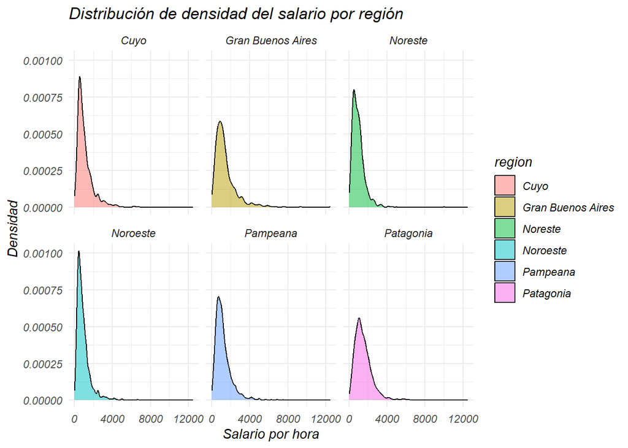

```r
ggplot(df, aes(x = salario_horario, fill = region)) +
  geom_density(alpha = 0.5) +
  labs(title = "Distribución de densidad del salario por región", x = "Salario por hora", y = "Densidad") +
  theme_minimal()+
  facet_wrap(~ region)
```

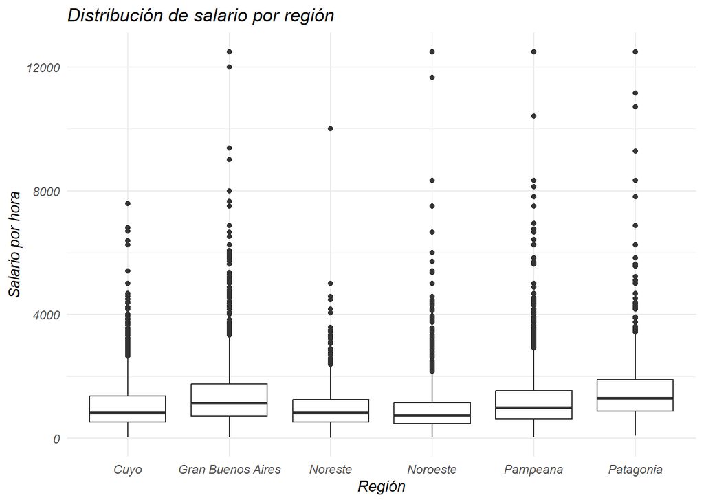

```r
ggplot(df, aes(x = region, y = salario_horario)) +
  geom_boxplot() +
  labs(title = "Distribución de salario por región", x = "Región", y = "Salario por hora") +
  theme_minimal()
```

Si bien los gráficos de densidad indican que la distribución del salario horario sigue la forma característica de un fenomeno económico en todas las regiones, los boxplot permiten visualizar que regiones como Gran Buenos Aires, Pampeana y Patagonia parecieran un salario por hora más alto que el resto

[figure not shown]

```r
ggplot(df, aes(x = salario_horario, fill = tipo_establecimiento)) +
  geom_density(alpha = 0.5) +
  labs(title = "Distribución de densidad del salario por región", x = "Salario por hora", y = "Densidad") +
  theme_minimal()
```

[figure not shown]

```r
ggplot(df, aes(x = tipo_establecimiento, y = salario_horario)) +
  geom_boxplot() +
  labs(title = "Distribución de salario por región", x = "Región", y = "Salario por hora") +
  theme_minimal()
```

De modo simiar, se aprecian ciertas diferencias en las medidas centrales de salario horario por tipo de establecimiento, resultado los estatales los que parecieran tener los valores más altos.

Primer modelo propio: Mincer + región + tipo de etablecimiento
$$\text{E [ln(SalarioHorario)] = β0 +β1 Años Educacion + β2 Experiencia
Potencial + β3 Experiencia Potencial^2+
β4Sexo + β5Sexo · AñosEducacion + β6 Región + β4 Tipo Establecimiento }$$

Para un segundo modelo, y de manera más exploratorioa, creamos la variables años_desde_educación para dar cuenta de hace cuanto las personas dejaron de estudiar.

```r
#Nuevas variables

df$anos_desde_educacion <- df$edad - df$educacion

matriz_sp2 <- df [, c("salario_horario", "anos_desde_educacion")]%>%
  correlate(method = 'spearman') %>%
  shave() %>%
  fashion(decimals = 3)
```

```
## Correlation computed with
## • Method: 'spearman'
## • Missing treated using: 'pairwise.complete.obs'
```

```r
matriz_sp2
```

| term | salario_horario | anos_desde_educacion |
| --- | --- | --- |
| salario_horario |  |  |
| anos_desde_educacion | .049 |  |

$$\text{E [ln(SalarioHorario)] = β0 +β1 Años Educacion + β2 Experiencia
Potencial + β3 Experiencia Potencial^2+
β4Sexo + β5Sexo · AñosEducacion + β6 Región + β4 Tipo Establecimiento +
β5Sexo · Región +
β6Sexo · Tipo Establecimiento + β7 Años Desde Educación }$$

```r
#Agregar al dataset las variables seleccionadas
df_1 <- cbind(df_1, df[, c("region", "tipo_establecimiento", "anos_desde_educacion")])
```

Definimos modelos

```r
modelo_prop_1 <- lm(log(salario_h) ~ educacion + exp_pot + exp_pot_cuad + sexo + sexo * educacion + region + tipo_establecimiento, data = df_1)

modelo_prop_2 <- lm(log(salario_h) ~ educacion + exp_pot + exp_pot_cuad + sexo + sexo * educacion + region + tipo_establecimiento + sexo*region + sexo*tipo_establecimiento + anos_desde_educacion , data = df_1)
```

Evaluación sobre dataset de train y prueba

```r
#Levanto Test
test <- read.csv("eph_test_2023.csv")
#glimpse(test)

#Analisis Test
exploratorio <- test %>%
  gather(., key="variables", value = "valores") %>%
  group_by(variables) %>%
  summarise(valores_unicos = n_distinct(valores),
  porcentaje_faltantes = sum(is.na(valores))/nrow(df)*100) %>%
  arrange(desc(porcentaje_faltantes), valores_unicos)

#exploratorio # No tiene Nan


#LO hago parecido a train.

#Cambio nombres
test <- test %>%
  rename(exp_pot=experiencia_potencial,
         salario_h=salario_horario)

#calculo exp_pot_cuad
test$exp_pot_cuad <- test$exp_pot^2

#calculo nuevas variables
test$anos_desde_educacion <- test$edad - test$educacion
```

```r
#Seleccionamos las mismas columnas que en train
test_1 <- test %>%
  select(colnames(df_1))
```

```r
#METRICAS EN TRAIN

# Predicciones del modelo Mincer en la escala original
predicciones_mincer <- exp(predict(modelo_mincer, newdata=df_1))

# Predicciones del modelo múltiple
predicciones_mult <- predict(modelo_mult, newdata=df_1)

# Predicciones del modelo propio 1
predicciones_prop_1 <- exp(predict(modelo_prop_1, newdata=df_1))

# Predicciones del modelo propio 2
predicciones_prop_2 <- exp(predict(modelo_prop_2, newdata=df_1))

# Calcular RMSE
RMSE_mincer <- sqrt(mean((df_1$salario_h - predicciones_mincer)^2))
RMSE_mult <- sqrt(mean((df_1$salario_h - predicciones_mult)^2))
RMSE_prop_1 <- sqrt(mean((df_1$salario_h - predicciones_prop_1)^2))
RMSE_prop_2 <- sqrt(mean((df_1$salario_h - predicciones_prop_2)^2))

# Calcular MAE
MAE_mincer <- mean(abs(df_1$salario_h - predicciones_mincer))
MAE_mult <- mean(abs(df_1$salario_h - predicciones_mult))
MAE_prop_1 <- mean(abs(df_1$salario_h - predicciones_prop_1))
MAE_prop_2 <- mean(abs(df_1$salario_h - predicciones_prop_2))


# Crear un data frame para comparar RMSE y MAE
df_comparacion_metrics <- data.frame(
  modelo = c("modelo_mincer", "modelo_mult", "propio_1", "propio_2"),
  RMSE = c(RMSE_mincer, RMSE_mult, RMSE_prop_1, RMSE_prop_2),
  MAE = c(MAE_mincer, MAE_mult, MAE_prop_1, MAE_prop_2)
)

# Ver el data frame de comparación
df_comparacion_metrics
```

| modelo | RMSE | MAE |
| --- | --- | --- |
| modelo_mincer | 910.2953 | 543.3399 |
| modelo_mult | 886.3628 | 570.3081 |
| propio_1 | 871.8570 | 506.8868 |
| propio_2 | 871.4732 | 506.1217 |

```r
# Predicciones del modelo Mincer en la escala original sobre test_1
predicciones_mincer_test <- exp(predict(modelo_mincer, newdata = test_1))

# Predicciones del modelo múltiple sobre test_1
predicciones_mult_test <- predict(modelo_mult, newdata = test_1)

# Predicciones del modelo propio 1 sobre test_1
predicciones_prop_1_test <- exp(predict(modelo_prop_1, newdata = test_1))

# Predicciones del modelo propio 2 sobre test_1
predicciones_prop_2_test <- exp(predict(modelo_prop_2, newdata = test_1)) #mejor es el 3, dps quedarse con ese

# Calcular RMSE
RMSE_mincer_test <- sqrt(mean((test_1$salario_h - predicciones_mincer_test)^2))
RMSE_mult_test <- sqrt(mean((test_1$salario_h - predicciones_mult_test)^2))
RMSE_prop_1_test <- sqrt(mean((test_1$salario_h - predicciones_prop_1_test)^2))
RMSE_prop_2_test <- sqrt(mean((test_1$salario_h - predicciones_prop_2_test)^2))

# Calcular MAE
MAE_mincer_test <- mean(abs(test_1$salario_h - predicciones_mincer_test))
MAE_mult_test <- mean(abs(test_1$salario_h - predicciones_mult_test))
MAE_prop_1_test <- mean(abs(test_1$salario_h - predicciones_prop_1_test))
MAE_prop_2_test <- mean(abs(test_1$salario_h - predicciones_prop_2_test))

# Crear un data frame para comparar RMSE y MAE
df_comparacion_metrics_test <- data.frame(
  modelo = c("modelo_mincer", "modelo_mult", "propio_1", "propio_2"),
  RMSE = c(RMSE_mincer_test, RMSE_mult_test, RMSE_prop_1_test, RMSE_prop_2_test),
  MAE = c(MAE_mincer_test, MAE_mult_test, MAE_prop_1_test, MAE_prop_2_test)
)

# Ver el data frame de comparación
df_comparacion_metrics_test
```

| modelo | RMSE | MAE |
| --- | --- | --- |
| modelo_mincer | 895.3646 | 532.3231 |
| modelo_mult | 872.1339 | 556.2401 |
| propio_1 | 848.9217 | 490.7974 |
| propio_2 | 846.8062 | 489.9393 |

Comparamos

```r
colnames(df_comparacion_metrics) <- c("modelo", "RMSE_train", "MAE_train")
colnames(df_comparacion_metrics_test) <- c("modelo", "RMSE_test", "MAE_test")

# Unir ambos data frames por el modelo
df_comparacion_total <- left_join(df_comparacion_metrics, df_comparacion_metrics_test, by = "modelo")

# Reordenar las columnas para que RMSE_train y RMSE_test estén lado a lado
df_comparacion_total <- df_comparacion_total %>%
  select(modelo, RMSE_train, RMSE_test, MAE_train, MAE_test)

# Ver el data frame de comparación total
df_comparacion_total
```

| modelo | RMSE_train | RMSE_test | MAE_train | MAE_test |
| --- | --- | --- | --- | --- |
| modelo_mincer | 910.2953 | 895.3646 | 543.3399 | 532.3231 |
| modelo_mult | 886.3628 | 872.1339 | 570.3081 | 556.2401 |
| propio_1 | 871.8570 | 848.9217 | 506.8868 | 490.7974 |
| propio_2 | 871.4732 | 846.8062 | 506.1217 | 489.9393 |

# 6. Modelo lineal robusto

```r
#Levanto Outliers
outliers <- read.csv("eph_train_outliers_2023.csv")

outliers <- outliers %>%
  rename(exp_pot=experiencia_potencial, salario_h=salario_horario)
```

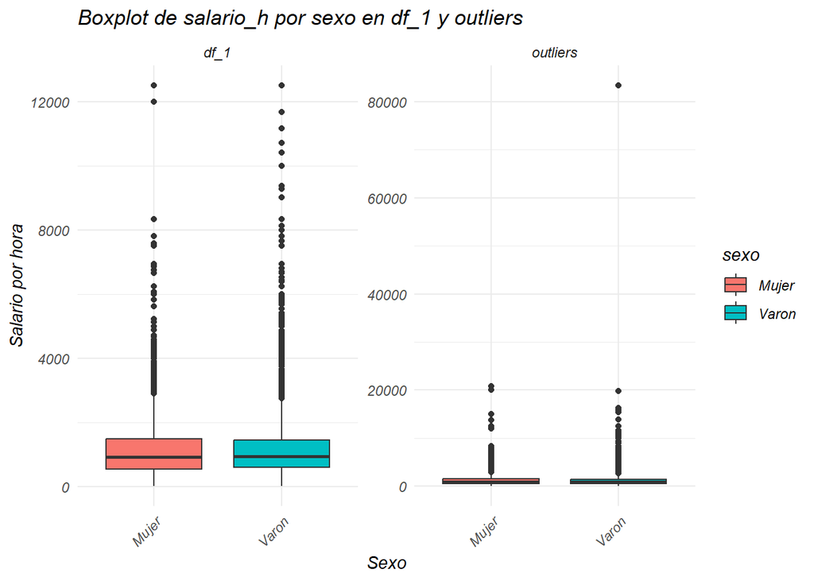

```r
# Crear un dataframe combinado para df_1 y outliers
df_1$dataset <- "df_1"
outliers$dataset <- "outliers"

# Combinar ambos datasets
df_combined <- rbind(df_1[, c("sexo", "salario_h", "dataset")], outliers[, c("sexo", "salario_h", "dataset")])

# Convertir los datasets a formato largo
df_long <- df_combined

# Crear el boxplot
ggplot(df_long, aes(x = sexo, y = salario_h, fill = sexo)) +
  geom_boxplot() +
  facet_wrap(~ dataset, scales = "free") +
  theme_minimal() +
  labs(title = "Boxplot de salario_h por sexo en df_1 y outliers", x = "Sexo", y = "Salario por hora") +
  theme(axis.text.x = element_text(angle = 45, hjust = 1))
```

La diferencia de escala y el menor ancho de la caja permite apreciar el efecto de los outliers en la visualizacion de los datos.

Sobre este nuevo conjunto de datos entrenar el modelo lineal multiple, el modelo de mincer y un modelo robusto (misma especificación que el modelo lineal multiple). Comparar exhaustivamente los coeficientes estimados y su significatividad entre el modelo lineal multiple y el modelo robusto. Comparar la performance (RMSE y MAE) de los tres modelos entrenados en este punto en el dataset de entrenamiento (con outliers) y de evaluación ¿Qué puede concluir al respecto?

```r
# Cargar la librería robustbase
#install.packages("robustbase")
library(robustbase)
outliers$exp_pot_cuad <- outliers$exp_pot^2

# Crear y entrenar el modelo multiple robusto
modelo_mult_robusto <- lmrob(salario_h ~ educacion + exp_pot + exp_pot_cuad + sexo + sexo*educacion, data = outliers)

# Entrenar modelo multiple y de mincer
modelo_mult_out <- lm(salario_h ~ educacion + exp_pot + exp_pot_cuad + sexo + sexo*educacion, data = outliers)
modelo_mincer_out <- lm(log(salario_h) ~ educacion + exp_pot + exp_pot_cuad + sexo + sexo * educacion, data = outliers)

# Ver el resumen del modelo robusto
#summary(modelo_mult_robusto)
#summary(modelo_mult_out)
```

```r
# Resumen de ambos modelos
summary_robusto <- summary(modelo_mult_robusto)
summary_out <- summary(modelo_mult_out)

# Extraer los coeficientes y p-values de ambos modelos
coef_robusto <- summary_robusto$coefficients[, c("Estimate", "Pr(>|t|)")]
coef_out <- summary_out$coefficients[, c("Estimate", "Pr(>|t|)")]


# Crear un dataframe comparativo sin duplicar los nombres de las variables
df_comparacion_coef <- data.frame(
  Estimado_Robusto = coef_robusto[, "Estimate"],
  Estimado_Out = coef_out[, "Estimate"],
  P_value_Robusto = coef_robusto[, "Pr(>|t|)"],
  P_value_Out = coef_out[, "Pr(>|t|)"]
)

# Ver el dataframe comparativo
df_comparacion_coef
```

|  | Estimado_Robusto | Estimado_Out | P_value_Robusto | P_value_Out |
| --- | --- | --- | --- | --- |
| (Intercept) | -484.5817041 | -899.0123745 | 7.737592e-34 | 3.468649e-29 |
| educacion | 87.5763221 | 123.6644457 | 3.018451e-203 | 2.187430e-131 |
| exp_pot | 20.6008518 | 21.1828906 | 4.256754e-57 | 3.244104e-13 |
| exp_pot_cuad | -0.2394063 | -0.1261313 | 1.195362e-21 | 2.274600e-02 |
| sexoVaron | 263.2209190 | 173.7931098 | 4.284345e-10 | 5.130801e-02 |
| educacion:sexoVaron | -13.5759909 | -1.0366409 | 9.569485e-05 | 8.727568e-01 |

Analizamos R2

```r
r2_robusto <- summary(modelo_mult_robusto)$r.squared
r2_out <- summary(modelo_mult_out)$r.squared

# Crear un dataframe comparativo para r2
df_comparacion_r2 <- data.frame(
  r2_robusto=r2_robusto,
  r2_out=r2_out
)

df_comparacion_r2
```

| r2_robusto | r2_out |
| --- | --- |
| 0.2003705 | 0.103471 |

A su vez el modelo robusto tiene un mejor R2, implicando una mejor capacidad explicativa sobre la variabilidad de salario_h

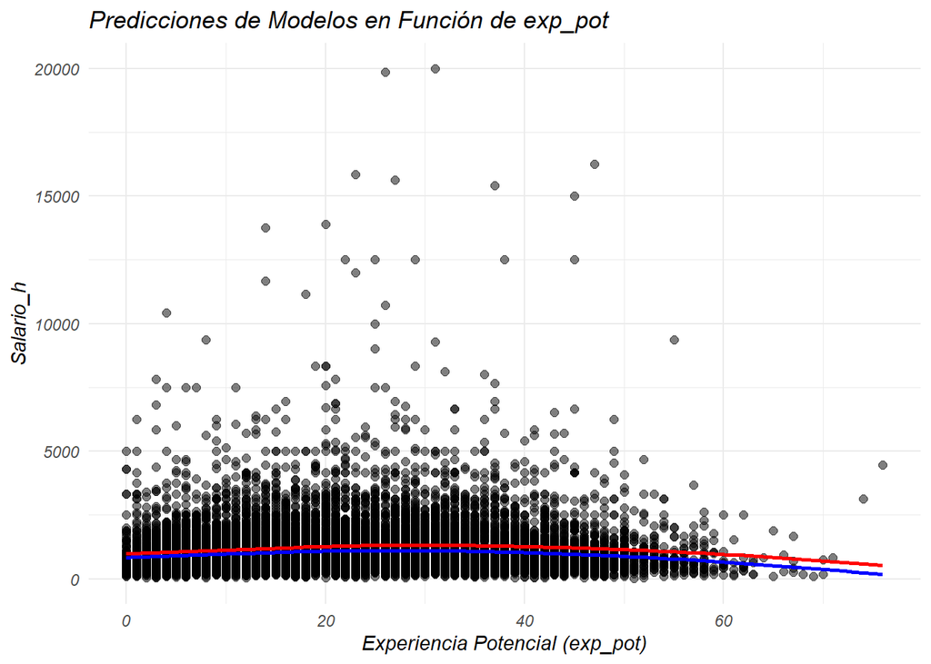

```r
library(ggplot2)

# Predicciones de los modelos sobre el dataset outliers
predicciones_robusto <- predict(modelo_mult_robusto, newdata = outliers)
predicciones_out <- predict(modelo_mult_out, newdata = outliers)

# Agregar las predicciones al dataframe outliers
outliers$predicciones_robusto <- predicciones_robusto
outliers$predicciones_out <- predicciones_out

# Graficar
ggplot(outliers, aes(x = exp_pot)) +
  geom_point(aes(y = salario_h), color = "black", alpha = 0.5, size = 2) + # Puntos de salario_h reales
  #geom_point(aes(y = predicciones_robusto), color = "blue", alpha = 0.5, size = 2, shape = 21, fill = "lightblue") +
  #geom_point(aes(y = predicciones_out), color = "red", alpha = 0.5, size = 2, shape = 21, fill = "lightpink") +
  geom_smooth(aes(y = predicciones_robusto), method = "loess", color = "blue", se = FALSE) +
  geom_smooth(aes(y = predicciones_out), method = "loess", color = "red", se = FALSE) +
  labs(title = "Predicciones de Modelos en Función de exp_pot",
       x = "Experiencia Potencial (exp_pot)",
       y = "Salario_h") +
  ylim(0, 20000) +
  theme_minimal()
```

Métricas en TRAIN

```r
# Predicciones de los modelos sobre el dataset outliers
predicciones_mult_out <- predict(modelo_mult_out, newdata = outliers)  # Modelo múltiple
predicciones_mult_robusto <- predict(modelo_mult_robusto, newdata = outliers)  # Modelo robusto
predicciones_mincer_out <- exp(predict(modelo_mincer_out, newdata = outliers))  # Modelo Mincer

# Calcular RMSE
RMSE_mult_out_train <- sqrt(mean((outliers$salario_h - predicciones_mult_out)^2))
RMSE_mult_robusto_train <- sqrt(mean((outliers$salario_h - predicciones_mult_robusto)^2))
RMSE_mincer_out_train <- sqrt(mean((outliers$salario_h - predicciones_mincer_out)^2))

# Calcular MAE
MAE_mult_out_train <- mean(abs(outliers$salario_h - predicciones_mult_out))
MAE_mult_robusto_train <- mean(abs(outliers$salario_h - predicciones_mult_robusto))
MAE_mincer_out_train <- mean(abs(outliers$salario_h - predicciones_mincer_out))

# Crear un data frame para comparar RMSE y MAE
df_comparacion_metrics_out_train <- data.frame(
  modelo = c("modelo_mult_out", "modelo_mult_robusto", "modelo_mincer_out"),
  RMSE = c(RMSE_mult_out_train, RMSE_mult_robusto_train, RMSE_mincer_out_train),
  MAE = c(MAE_mult_out_train, MAE_mult_robusto_train, MAE_mincer_out_train)
)

# Ver el data frame de comparación
df_comparacion_metrics_out_train
```

| modelo | RMSE | MAE |
| --- | --- | --- |
| modelo_mult_out | 1242.741 | 595.8567 |
| modelo_mult_robusto | 1266.005 | 568.2402 |
| modelo_mincer_out | 1264.851 | 562.7355 |

```r
# Predicciones de los modelos sobre el dataset test_1
predicciones_mult_out_test <- predict(modelo_mult_out, newdata = test_1)
predicciones_mult_robusto_test <- predict(modelo_mult_robusto, newdata = test_1)
predicciones_mincer_out_test <- exp(predict(modelo_mincer_out, newdata = test_1))

# Calcular RMSE
RMSE_mult_out_test <- sqrt(mean((test_1$salario_h - predicciones_mult_out_test)^2))
RMSE_mult_robusto_test <- sqrt(mean((test_1$salario_h - predicciones_mult_robusto_test)^2))
RMSE_mincer_out_test <- sqrt(mean((test_1$salario_h - predicciones_mincer_out_test)^2))

# Calcular MAE
MAE_mult_out_test <- mean(abs(test_1$salario_h - predicciones_mult_out_test))
MAE_mult_robusto_test <- mean(abs(test_1$salario_h - predicciones_mult_robusto_test))
MAE_mincer_out_test <- mean(abs(test_1$salario_h - predicciones_mincer_out_test))

# Crear un data frame para comparar RMSE y MAE
df_comparacion_metrics_out_test <- data.frame(
  modelo = c("modelo_mult_out", "modelo_mult_robusto", "modelo_mincer_out"),
  RMSE = c(RMSE_mult_out_test, RMSE_mult_robusto_test, RMSE_mincer_out_test),
  MAE = c(MAE_mult_out_test, MAE_mult_robusto_test, MAE_mincer_out_test)
)

# Ver el data frame de comparación
df_comparacion_metrics_out_test
```

| modelo | RMSE | MAE |
| --- | --- | --- |
| modelo_mult_out | 873.1666 | 561.7370 |
| modelo_mult_robusto | 895.3467 | 536.5903 |
| modelo_mincer_out | 894.2690 | 532.0463 |

```r
colnames(df_comparacion_metrics_out_train) <- c("modelo", "RMSE_train", "MAE_train")
colnames(df_comparacion_metrics_out_test) <- c("modelo", "RMSE_test", "MAE_test")

# Unir ambos data frames por el modelo
df_comparacion_total_out <- left_join(df_comparacion_metrics_out_train, df_comparacion_metrics_out_test, by = "modelo")

# Reordenar las columnas para que RMSE_train y RMSE_test estén lado a lado
df_comparacion_total_out <- df_comparacion_total_out %>%
  select(modelo, RMSE_train, RMSE_test, MAE_train, MAE_test)

# Ver el data frame de comparación total
df_comparacion_total_out
```

| modelo | RMSE_train | RMSE_test | MAE_train | MAE_test |
| --- | --- | --- | --- | --- |
| modelo_mult_out | 1242.741 | 873.1666 | 595.8567 | 561.7370 |
| modelo_mult_robusto | 1266.005 | 895.3467 | 568.2402 | 536.5903 |
| modelo_mincer_out | 1264.851 | 894.2690 | 562.7355 | 532.0463 |